# Exercise_9

Chenwei Xiao

2020/11/11

## Hands on Logistic Regression

IMPORTANT NOTE: You have to solve the exercise using the keras library.

Questions:

1. Read in the data, tokenize the iris type (so that the output is a number) into a new column with name “y”. Namely, “virginica” –> 1, “not_virginica” –> 0
2. Shuffle your data and create a train and test set with proportions 80% and 20% of the given data respectively.
3. Plot the training data and give a different color for each type.
4. Create a Logistic Regression Model
5. Plot the training data as in question 3 and also include the derived decision boundary (and Sigmoid output for configuration a) from the fitted model.
6. Evaluate the accuracy of the model in the test set.
7. Plot the testing data (use different colors for each Type), include the decision boundary from the fitted model and also use different point type for the misclassified predictions (if any).

You have to solve questions 3-7 with 2 different configurations.

1. Using only the Petal Width as predictor
2. Using both Petal Length and Petal Width as predictors

A skeleton code is provided below:

#### Import required libraries

```r
library(tidyverse)
library(reticulate)
use_condaenv()
library(keras)
library(tensorflow)
```

[output not shown]

#### Read Data

```r
data = read.csv('../../data/exercise/data_iris.csv')
head(data)
```

```
##   Petal_Length Petal_Width          Type
## 1          1.4         0.2 not_virginica
## 2          1.4         0.2 not_virginica
## 3          1.3         0.2 not_virginica
## 4          1.5         0.2 not_virginica
## 5          1.4         0.2 not_virginica
## 6          1.7         0.4 not_virginica
```

#### Tokenize Type

```r
#create a new column with name y where y=1 defines virginica while y=0 defines not_virginica

#YOUR SOLUTION HERE
#HINT: Use the ifelse function
data$y = ifelse(data$Type=='not_virginica',0,1)
head(data)
```

```
##   Petal_Length Petal_Width          Type y
## 1          1.4         0.2 not_virginica 0
## 2          1.4         0.2 not_virginica 0
## 3          1.3         0.2 not_virginica 0
## 4          1.5         0.2 not_virginica 0
## 5          1.4         0.2 not_virginica 0
## 6          1.7         0.4 not_virginica 0
```

```r
#YOUR SOLUTION HERE -> shuffle the data and make the train,test split
#shuffle data
set.seed(42)
shuffle = sample(x=1:nrow(data),size = nrow(data),replace = FALSE)
data = data[shuffle,]
head(data)
```

```
##     Petal_Length Petal_Width          Type y
## 49           1.5         0.2 not_virginica 0
## 65           3.6         1.3 not_virginica 0
## 74           4.7         1.2 not_virginica 0
## 146          5.2         2.3     virginica 1
## 122          4.9         2.0     virginica 1
## 150          5.1         1.8     virginica 1
```

```r
#split data
breakpoint = as.integer(0.8 * nrow(data)) # 80% train set

#Create train and test set
df_train = data %>% slice(1:breakpoint)
df_test = data %>% slice((breakpoint+1):nrow(data))

#create input and output

x_train = df_train[,c('Petal_Length', 'Petal_Width')]
y_train= df_train$y

x_test = df_test[,c('Petal_Length', 'Petal_Width')]
y_test = df_test$y
```

### Configuration a

#### Plot the training data

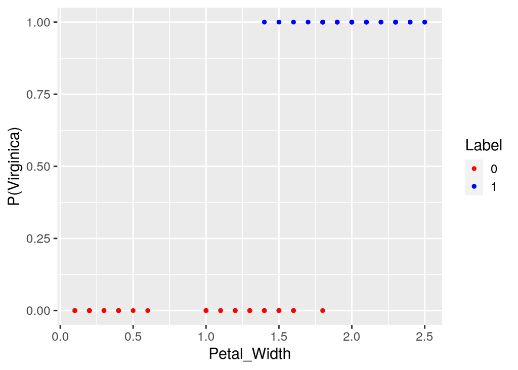

```r
#YOUR SOLUTION HERE: use only the Petal Width as input
df_train %>%
    ggplot(aes(x = Petal_Width , y = y , color = as.factor(y)))+
    geom_point()+
    scale_color_manual(name = 'Label',values = c('0' = 'red','1' = 'blue'))+
    ylab("P(Virginica)")+
    theme_grey(base_size = 15)
```

#### Create the model

```r
#YOUR SOLUTION HERE
#fill in what is missing
# you have to use the right activation and loss function for logistic regression

 use_session_with_seed(42)
 model_a = keras_model_sequential()

 model_a %>% layer_dense(units = 1,activation = 'sigmoid')

 opt = optimizer_adam(lr=0.1)

 model_a %>% compile(loss = 'binary_crossentropy',optimizer = opt, metrics = 'accuracy')

 model_a %>% fit(x= x_train$Petal_Width,y=y_train,epochs=20,batch_size=32)

 w_a = unlist(get_weights(model_a))
 w_a
```

```
## [1]  2.144345 -3.422956
```

#### Plot the decision boundary

```r
#Your solution
# Decision boundary: 2.144345*x - 3.422956 = 0
x_bound <- -w_a[2]/w_a[1]
cat('Decision boundary for petal width is: ',x_bound)
```

```
## Decision boundary for petal width is:  1.596271
```

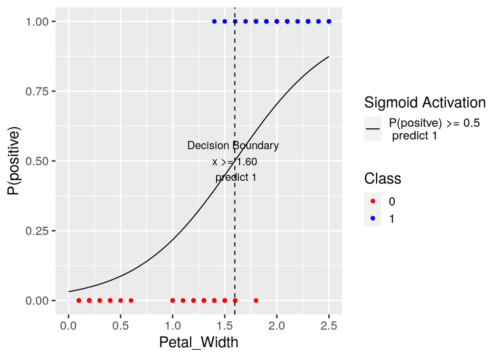

```r
#create a grid of values ranging from 0 to 2.5
grid = seq(from = 0 ,to = 2.5,length.out = 100)
df = data.frame(x = grid)
#take predictions --> it is probability of an instance to belong to the positive class
pred = predict(model_a, x = grid)
df_pred = data.frame(grid = grid,pred = pred)

df_train %>%
    ggplot(aes(x = Petal_Width,y = y , color = as.factor(y)))+
    geom_point()+
    geom_line(data = df_pred, aes(x = grid,y = pred,linetype = 'Sigmoid'),color = 'black')+
    geom_vline(xintercept = x_bound, lty = 2)+
    annotate('text',x = x_bound ,y = 0.5,label = 'Decision Boundary \n x >= 1.60 \n predict 1')+
    scale_color_manual(name = 'Class',values = c('0' = 'red','1' = 'blue'))+
    scale_linetype_manual(name = 'Sigmoid Activation',values = 1,labels = 'P(positve) >= 0.5 \n predict 1 ')+
    ylab("P(positive)")+
    theme_grey(base_size = 15)
```

#### Evaluate the accuracy of the model in the test set

```r
#YOUR SOLUTION HERE
#fill in what is missing

# take probabilities
p_nn = predict(model_a,x_test$Petal_Width)

#make decisions
pred = (p_nn >= 0.5)*1

# accuracy

accuracy = mean(pred == y_test)

cat("Test Accuracy: ",round(accuracy,3),'\n')
```

```
## Test Accuracy:  0.933
```

#### Plot misclassified predictions in the test data

```r
#YOUR SOLUTION
# HINT: create a new column in the df_test which indicates those points that are misclassified
df_test$misclass <- (pred != y_test)*1
head(df_test)
```

```
##   Petal_Length Petal_Width          Type y misclass
## 1          5.3         2.3     virginica 1        0
## 2          4.8         1.8     virginica 1        0
## 3          5.6         2.2     virginica 1        0
## 4          5.6         2.4     virginica 1        0
## 5          5.5         1.8     virginica 1        0
## 6          4.5         1.5 not_virginica 0        0
```

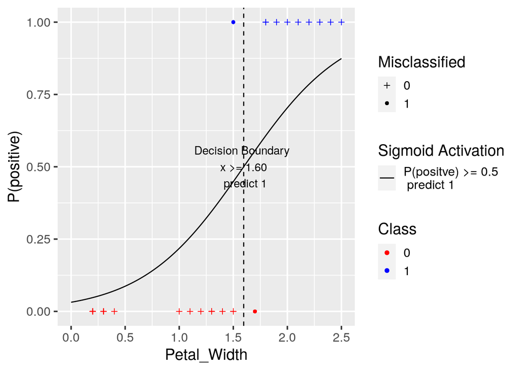

```r
df_test %>%
    ggplot(aes(x = Petal_Width,y = y , color = as.factor(y)))+
    geom_point(aes(shape = as.factor(df_test$misclass)))+
    geom_line(data = df_pred, aes(x = grid,y = pred,linetype = 'Sigmoid'),color = 'black')+
    geom_vline(xintercept = x_bound, lty = 2)+
    annotate('text',x = x_bound ,y = 0.5,label = 'Decision Boundary \n x >= 1.60 \n predict 1')+
    scale_color_manual(name = 'Class',values = c('0' = 'red','1' = 'blue'))+
    scale_shape_manual(name = 'Misclassified', values=c(3,16))+
    scale_linetype_manual(name = 'Sigmoid Activation',values = 1,labels = 'P(positve) >= 0.5 \n predict 1 ')+
    ylab("P(positive)")+
    theme_grey(base_size = 15)
```

### Configuration b

#### Plot the training data

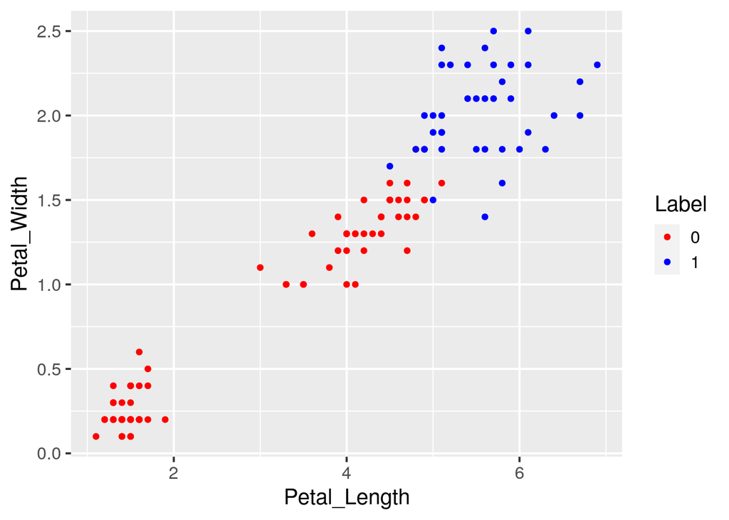

```r
#YOUR SOLUTION HERE: use both the Petal Length and Petal Width as inputs
#HINT your x=Petal_Length,y=Petal_Width
df_train %>%
    ggplot(aes(x = Petal_Length , y = Petal_Width , color = as.factor(y)))+
    geom_point()+
    scale_color_manual(name = 'Label',values = c('0' = 'red','1' = 'blue'))+
    theme_grey(base_size = 15)
```

#### Create the model

```r
#YOUR SOLUTION HERE
#fill in what is missing
# you have to use the right activation and loss function for logistic regression


use_session_with_seed(42)

model_b = keras_model_sequential()

model_b %>% layer_dense(units = 1,activation = 'sigmoid')

opt = optimizer_adam(lr=0.1)

model_b %>% compile(loss = 'binary_crossentropy',optimizer = opt, metrics = 'accuracy')

model_b %>% fit(x=as.matrix(x_train),y=y_train,epochs=30,batch_size=32)

w_b = unlist(get_weights(model_b))
w_b
```

```
## [1]  0.3458101  1.4265333 -4.0034528
```

#### Plot the decision boundary

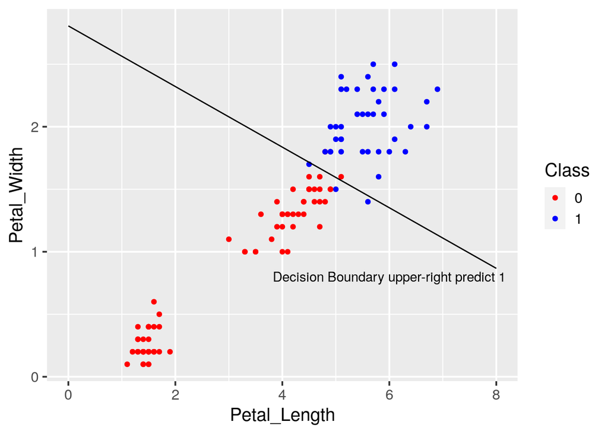

```r
#Your solution
#HINT: Your desicion boundary now is a line
# Desicion boundary: 0.3458101*x + 1.4265333*y -4.0034528 = 0
x_bound <- seq(from = 0 ,to = 8,length.out = 100)
y_bound <- (-w_b[3]-w_b[1]*x_bound)/w_b[2]
df_bound <- data.frame(x = x_bound,y = y_bound)
df_train %>%
    ggplot(aes(x = Petal_Length , y = Petal_Width , color = as.factor(y)))+
    geom_point()+
    geom_line(data = df_bound, aes(x = x,y = y),color = 'black')+
    annotate('text',x = 6 ,y = 0.8,label = 'Decision Boundary upper-right predict 1')+
    scale_color_manual(name = 'Class',values = c('0' = 'red','1' = 'blue'))+
    scale_linetype_manual(name = 'Decision Boundary',values = 1,labels = 'Upper-right predict 1 ')+
    theme_grey(base_size = 15)
```

#### Evaluate the accuracy of the model in the test set

```r
#YOUR SOLUTION HERE
#fill in what is missing


# take probabilities
p_nn = predict(model_b,as.matrix(x_test))

#make decisions
pred = (p_nn >= 0.5)*1

# accuracy

accuracy = mean(pred == y_test)

cat("Test Accuracy: ",round(accuracy,3),'\n')
```

```
## Test Accuracy:  0.933
```

#### Plot misclassified predictions in the test data

```r
#YOUR SOLUTION
# HINT: create a new column in the df_test which indicates those points that are misclassified
df_test$misclassb <- (pred != y_test)*1
head(df_test)
```

```
##   Petal_Length Petal_Width          Type y misclass misclassb
## 1          5.3         2.3     virginica 1        0         0
## 2          4.8         1.8     virginica 1        0         0
## 3          5.6         2.2     virginica 1        0         0
## 4          5.6         2.4     virginica 1        0         0
## 5          5.5         1.8     virginica 1        0         0
## 6          4.5         1.5 not_virginica 0        0         0
```

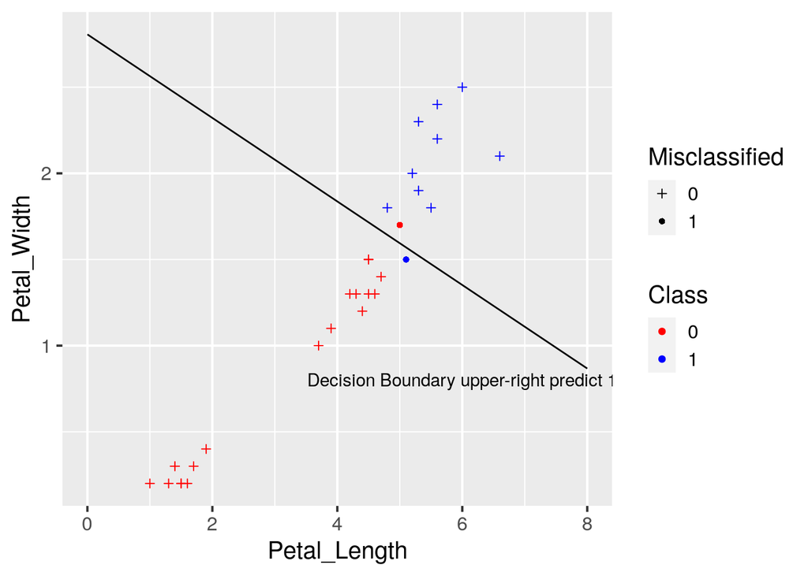

```r
df_test %>%
    ggplot(aes(x = Petal_Length , y = Petal_Width , color = as.factor(y)))+
    geom_point(aes(shape = as.factor(df_test$misclassb)))+
    geom_line(data = df_bound, aes(x = x,y = y),color = 'black')+
    annotate('text',x = 6 ,y = 0.8,label = 'Decision Boundary upper-right predict 1')+
    scale_color_manual(name = 'Class',values = c('0' = 'red','1' = 'blue'))+
    scale_shape_manual(name = 'Misclassified', values=c(3,16))+
    scale_linetype_manual(name = 'Decision Boundary',values = 1,labels = 'Upper-right predict 1 ')+
    theme_grey(base_size = 15)
```